# Maximum Likelihood and related topics

###### By Rohit Pardasani

In statistics and machine learning :  
We generally draw samples from an underlying population which has a distribution.  
This distribution has obviously will have some parameters, which might be unknown.  
We may just have a sample set drawn from the distribution and we may just know the type of distribution, but nothing about the parameters of distribution  
How do we estimate parameters of distribution from a sample set drawn from the distribution ?

## Likelihood Function

Let's say we draw a sample with value $x$ from a distribution with some paramter value as $\theta$ (it's unknown).  
What is probability that value of parameter value is $\theta$ given that sample x was drawn from distribution  
$\mathcal{L(\theta|x)}$ = Likelihood of $\theta$ given $x$ = $P(X=x|\theta)$  
Since this is not conditional probability, therefore written as :  
$\mathcal{L(\theta|x)} = p_\theta(x) = P_\theta(X=x) = P(X=x;\theta)$ in discrete case  
$\mathcal{L(\theta|x)} = f_\theta(x)$ in continuous case  
What happens when we draw more than one sample ?  
The likelihood function (often simply called the likelihood) describes the joint probability of the observed data as a function of the parameters of the chosen statistical model.  
$\mathcal{L}(\theta|x)$, here $x$ is not a single sample but a dataset say $\mathcal{L}(\theta|x_1,x_2,x_3..x_n)$

#### Example:

We draw $n$ samples from a Bernoulli Distribution which has success probability of $p_0$.  
$p_0$ is unknown to us  
We just have samples $x_1,x_2,x_3.....,x_n$  
Since samples are from Bernoulli Distribution, $x_i$ could be either 1 or 0  
Let us assumme that success probability is $p$ for the underlying distribution  
$\mathcal{L(p|x)}$ = Probability of getting set of $x_i$'s if success proability is $p$  
$\mathcal{L(p|x)}$ = $P(x_1;p)P(x_2;p)P(x_3;p)...P(x_n;p)$ (since all events are independent of each other)  
Let's say out of $n$ $x_i$'s, k are 1 and rest are 0  
$\mathcal{L(p|x)} = p^k(1-p)^{n-k}$

#### Log Likelihood

We also define **log of likelihood** as:  
$log (\mathcal{L}(p|x)) = l(p|x) = k log (p) + (n-k)log(1-p)$ (Log is generally natural log)

### Maximum Likelihood Estimate (MLE)

Maximum likelihood estimation (MLE) is a method of estimating the parameters of an assumed probability distribution, given some observed data.  
This is achieved by maximizing a likelihood function so that, under the assumed statistical model, the observed data is most probable.  
The point in the parameter space that maximizes the likelihood function is called the maximum likelihood estimate.  
MLE of $\theta$ = $\hat{\theta} = \underset{\theta\in\Theta}{\arg\max}\mathcal{L(\theta|x)}$  
Or we can also use log likelihood  
MLE of $\theta$ = $\hat{\theta} = \underset{\theta\in\Theta}{\arg\max} \mathcal{l(\theta|x)}$  
Can be calculated by putting  
$\frac{\partial \mathcal{L}(\theta|x)}{\partial \theta} = 0$  
OR  
$\frac{\partial \mathcal{l}(\theta|x)}{\partial \theta} = 0$

### From the likelihood function in above Bernoulli Distribution example calculating MLE of p<sub>0</sub>

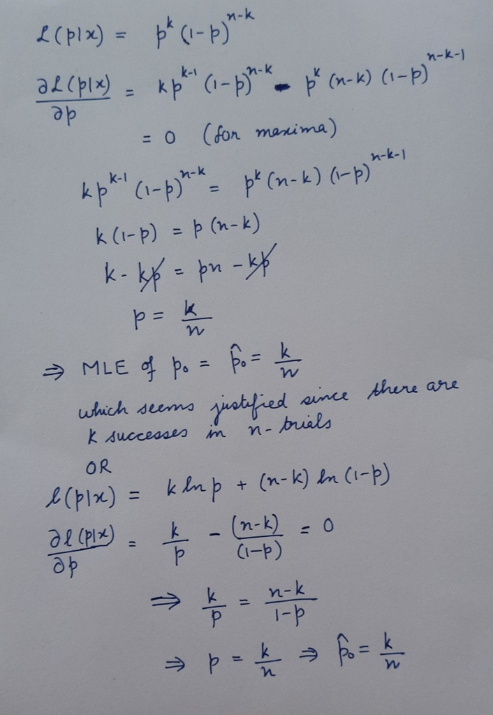

## Mixture Model

A mixture model is a probabilistic model for representing the presence of subpopulations within an overall population, without requiring that an observed data set should identify the sub-population to which an individual observation belongs.

## Gaussian Mixture Model (GMM)

Here the undelying population distribution is a mixture of Gaussians.  
Generally, we have samples from this mixture distribution but don't know the parameters of this distribution.  
Finding the undelying mixture Gaussian distribution can categorized as a clustering algorithm.

#### Example:

Consider that we draw n samples from the distribution show below  
The below distribution is a mixture of two Gaussian distributions $f_1(x)$ and $f_2(x)$  
$f(x) = \lambda_1f_1(x)+\lambda_2f_2(x)$  
$f_1(x) = \frac{1}{\sigma_1\sqrt{2\pi}}\exp\left( -\frac{1}{2}\left(\frac{x-\mu_1}{\sigma_1}\right)^{\!2}\,\right)$  
$f_2(x) = \frac{1}{\sigma_2\sqrt{2\pi}}\exp\left( -\frac{1}{2}\left(\frac{x-\mu_2}{\sigma_2}\right)^{\!2}\,\right)$  
Generally, $\lambda_1$,$\lambda_2$,$\mu_1$,$\mu_2$,$\sigma_1$,$\sigma_2$ will be unknown.

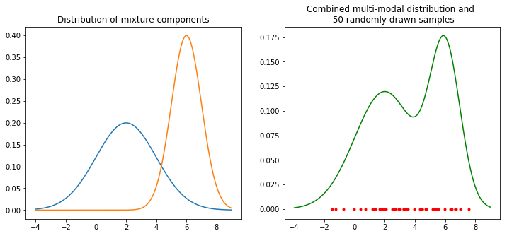

```python
import matplotlib.pyplot as plt
from scipy.stats import norm
import numpy as np
from numpy.random import choice
np.random.seed(3)
x = np.arange(-4,9,0.01)
y1 = norm.pdf(x,loc=2,scale=2)
y2 = norm.pdf(x,loc=6,scale=1)
figure, axis = plt.subplots(1, 2,figsize=(12,5))
y = 0.6*y1 + 0.4*y2
list_of_candidates = x
number_of_items_to_pick = 50
probability_distribution = y/sum(y)
draw = choice(list_of_candidates,number_of_items_to_pick,p=probability_distribution,replace=True)
axis[0].plot(x,y1)
axis[0].plot(x,y2)
axis[0].set_title('Distribution of mixture components')
axis[1].plot(x,y,color='green')
axis[1].scatter(draw,np.array([0]*len(draw)),marker='.',color='red')
axis[1].set_title('Combined multi-modal distribution and \n 50 randomly drawn samples')
plt.show()
```

## Maximum Likelihood Expectation Maximization (MLEM)

The expectation-maximization algorithm is an approach for performing maximum likelihood estimation in the presence of latent variables.  
It does this by first estimating the values for the latent variables, then optimizing the model, then repeating these two steps until convergence.  
It is an effective and general approach and is most commonly used for density estimation with missing data, such as clustering algorithms like the Gaussian Mixture Model.

### Using MLEM for estimating parameters of GMM

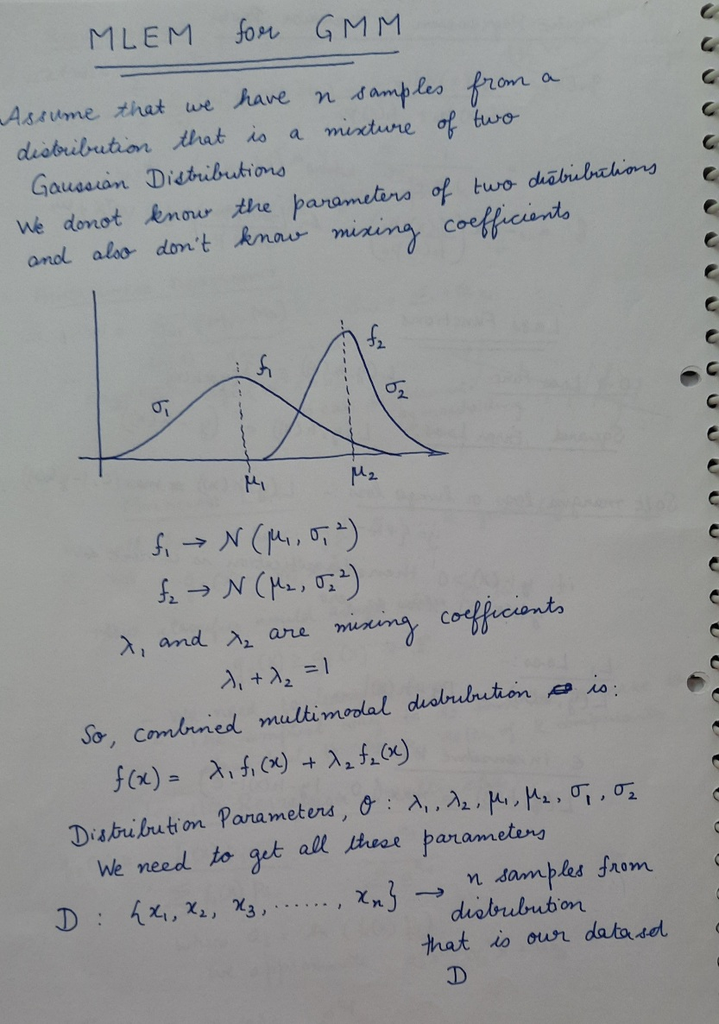

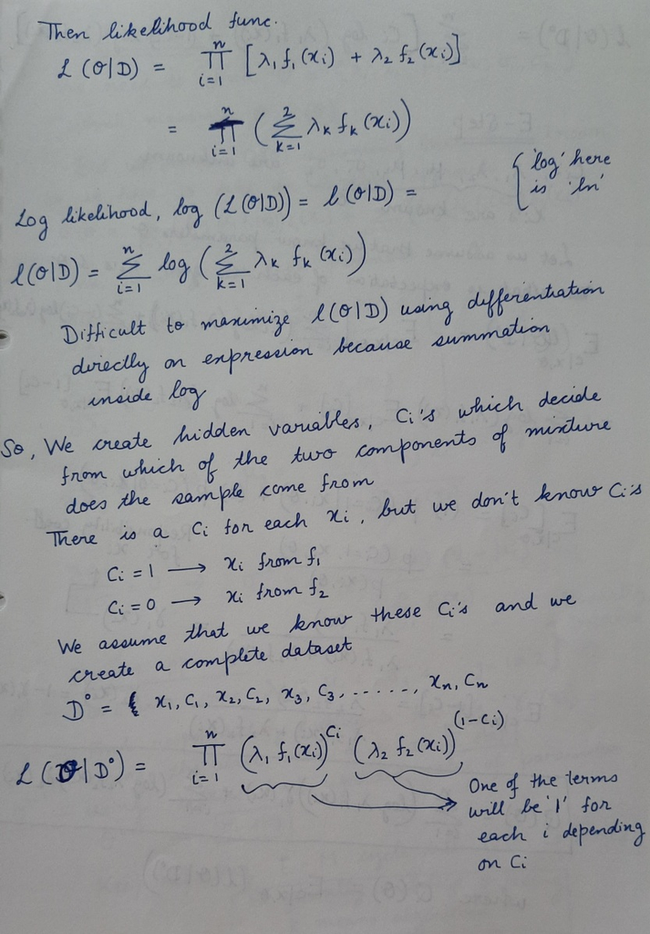

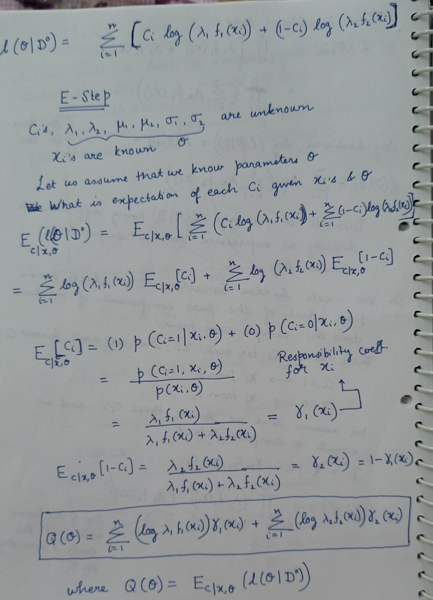

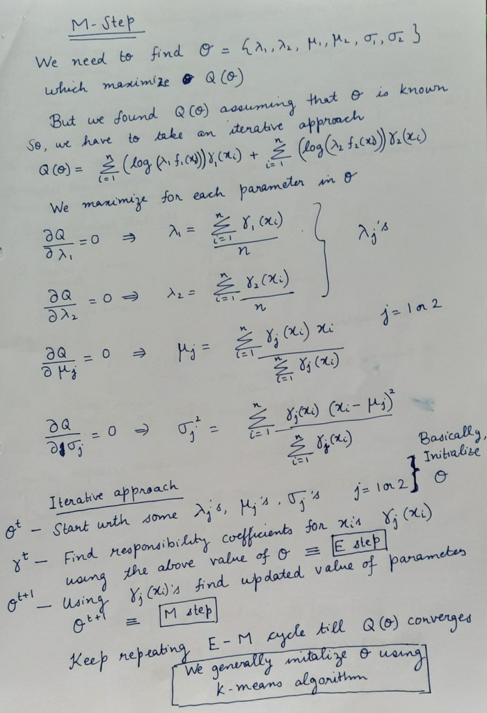

### Fitting Gaussian Mixture Model using sklearn

**(which uses EM Algorithm for finding parameters)**

Consider that we draw 300 samples from the distribution show below  
The below distribution is a mixture of two Gaussian distributions $f_1(x)$ and $f_2(x)$  
$f(x) = \lambda_1f_1(x)+\lambda_2f_2(x)$  
$f_1(x) = \frac{1}{\sigma_1\sqrt{2\pi}}\exp\left( -\frac{1}{2}\left(\frac{x-\mu_1}{\sigma_1}\right)^{\!2}\,\right)$  
$f_2(x) = \frac{1}{\sigma_2\sqrt{2\pi}}\exp\left( -\frac{1}{2}\left(\frac{x-\mu_2}{\sigma_2}\right)^{\!2}\,\right)$  
Let's assume that  
$\mu_1 = 2$  
$\mu_2 = 6$  
$\sigma_1 = 2,{\sigma_1}^{2} = 4 $  
$\sigma_2 = 1,{\sigma_2}^{2} = 1 $  
$\lambda_1 = 0.6$  
$\lambda_2 = 0.4$

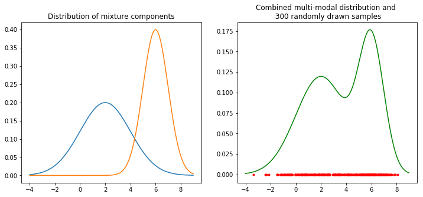

```python
import matplotlib.pyplot as plt
from scipy.stats import norm
import numpy as np
from numpy.random import choice
np.random.seed(7)
x = np.arange(-4,9,0.01)
y1 = norm.pdf(x,loc=2,scale=2)
y2 = norm.pdf(x,loc=6,scale=1)
figure, axis = plt.subplots(1, 2,figsize=(12,5))
y = 0.6*y1 + 0.4*y2
list_of_candidates = x
number_of_items_to_pick = 300
probability_distribution = y/sum(y)
draw = choice(list_of_candidates,number_of_items_to_pick,p=probability_distribution,replace=True)
axis[0].plot(x,y1)
axis[0].plot(x,y2)
axis[0].set_title('Distribution of mixture components')
axis[1].plot(x,y,color='green')
axis[1].scatter(draw,np.array([0]*len(draw)),marker='.',color='red')
axis[1].set_title('Combined multi-modal distribution and \n 300 randomly drawn samples')
plt.show()
```

```python
from sklearn.mixture import GaussianMixture
drawX = draw.reshape(-1,1)
gm = GaussianMixture(n_components=2, random_state=0).fit(drawX)
print('After fitting the model :\n')
print('Mixture Component 1:  Coeff= %.2f,  Mean=%.2f  Var=%.2f\n'%(gm.weights_[1], gm.means_[1][0], gm.covariances_[1][0][0]))
print('Mixture Component 2:  Coeff= %.2f,  Mean=%.2f  Var=%.2f\n'%(gm.weights_[0], gm.means_[0][0], gm.covariances_[0][0][0]))
```

```
After fitting the model :

Mixture Component 1:  Coeff= 0.56,  Mean=1.66  Var=3.25

Mixture Component 2:  Coeff= 0.44,  Mean=5.86  Var=1.05
```